# Nonlinear Models (ISL 7)

Biostat 212A

Author

Dr. Jin Zhou @ UCLA

Published

February 17, 2026

Credit: This note heavily uses material from the books [*An Introduction to Statistical Learning: with Applications in R*](https://www.statlearning.com/) (ISL2) and [*Elements of Statistical Learning: Data Mining, Inference, and Prediction*](https://hastie.su.domains/ElemStatLearn/) (ESL2).

Display system information for reproducibility.

**R**

**Python**

```python
import IPython
print(IPython.sys_info())
```

```
{'commit_hash': '5ed988a91',
 'commit_source': 'installation',
 'default_encoding': 'utf-8',
 'ipython_path': '/Users/jinjinzhou/.virtualenvs/r-tensorflow/lib/python3.10/site-packages/IPython',
 'ipython_version': '8.33.0',
 'os_name': 'posix',
 'platform': 'macOS-15.7.3-arm64-arm-64bit',
 'sys_executable': '/Users/jinjinzhou/.virtualenvs/r-tensorflow/bin/python',
 'sys_platform': 'darwin',
 'sys_version': '3.10.16 (main, Mar  3 2025, 20:01:33) [Clang 16.0.0 '
                '(clang-1600.0.26.6)]'}
```

## 1 Overview

- The truth is never linear! Or almost never!

  But often the linearity assumption is good enough.
- When it’s not …
  - polynomials
  - step functions
  - spline
  - local regression, and
  - generalized additive models

  offer a lot of flexibility, without losing the ease and interpretability of linear models.
- Main idea
  - To augment/replace the vector of inputs $X$ with additional variables, which are transformations of $X$, and then use linear models in this new space of derived input features.
  - For example, in regression problems, $f(X) = \mbox{E}(Y\mid X)$ is modeled as a linear function of $X$, but now to model is by transformation of $X$, i.e., $h_m(X)$.

$$f(X) =\sum_{m=1}^M \beta_m h_m(X)$$

- The beauty of this approach is that once the basis functions $h_m$ have been determined, the models are linear in these new variables, and the fitting proceeds as for linear models.

### 1.1 Popular choices for basis functions $h_m(X)$

- $h_m(X) = X_m, m = 1,\ldots,p$ recovers the original linear model
- $h_m(X) = X_j^2$ or $h_m(X) = X_jX_k$ allows us to augment the inputs with polynomial terms. Note, however, that the number of variables grows exponentially in the degree of the polynomial. A full quadratic model in $p$ variables requires $O(p^2)$ square and cross-product terms, or more generally $O(p^d)$ for a degree-d polynomial.
- $h_m(X) = \mathbf{I}(L_m \leq X_k < U_m)$, an indicator for a region of $X_k$. By breaking the range of $X_k$ up into $M_k$ such nonoverlapping regions results in a model with a piecewise constant contribution for $X_k$.
- `wage` vs `age`:

**R**

```r
library(gtsummary)
library(ISLR2)
library(tidyverse)

# Convert to tibble
Wage <- as_tibble(Wage) %>% print(width = Inf)
```

```
# A tibble: 3,000 × 11
    year   age maritl           race     education       region
   <int> <int> <fct>            <fct>    <fct>           <fct>
 1  2006    18 1. Never Married 1. White 1. < HS Grad    2. Middle Atlantic
 2  2004    24 1. Never Married 1. White 4. College Grad 2. Middle Atlantic
 3  2003    45 2. Married       1. White 3. Some College 2. Middle Atlantic
 4  2003    43 2. Married       3. Asian 4. College Grad 2. Middle Atlantic
 5  2005    50 4. Divorced      1. White 2. HS Grad      2. Middle Atlantic
 6  2008    54 2. Married       1. White 4. College Grad 2. Middle Atlantic
 7  2009    44 2. Married       4. Other 3. Some College 2. Middle Atlantic
 8  2008    30 1. Never Married 3. Asian 3. Some College 2. Middle Atlantic
 9  2006    41 1. Never Married 2. Black 3. Some College 2. Middle Atlantic
10  2004    52 2. Married       1. White 2. HS Grad      2. Middle Atlantic
   jobclass       health         health_ins logwage  wage
   <fct>          <fct>          <fct>        <dbl> <dbl>
 1 1. Industrial  1. <=Good      2. No         4.32  75.0
 2 2. Information 2. >=Very Good 2. No         4.26  70.5
 3 1. Industrial  1. <=Good      1. Yes        4.88 131.
 4 2. Information 2. >=Very Good 1. Yes        5.04 155.
 5 2. Information 1. <=Good      1. Yes        4.32  75.0
 6 2. Information 2. >=Very Good 1. Yes        4.85 127.
 7 1. Industrial  2. >=Very Good 1. Yes        5.13 170.
 8 2. Information 1. <=Good      1. Yes        4.72 112.
 9 2. Information 2. >=Very Good 1. Yes        4.78 119.
10 2. Information 2. >=Very Good 1. Yes        4.86 129.
# ℹ 2,990 more rows
```

```r
# Summary statistics
Wage %>% tbl_summary()
```

| **Characteristic** | **N = 3,000**<sup>1</sup> |
| --- | --- |
| year |  |
| 2003 | 513 (17%) |
| 2004 | 485 (16%) |
| 2005 | 447 (15%) |
| 2006 | 392 (13%) |
| 2007 | 386 (13%) |
| 2008 | 388 (13%) |
| 2009 | 389 (13%) |
| age | 42 (34, 51) |
| maritl |  |
| 1. Never Married | 648 (22%) |
| 2. Married | 2,074 (69%) |
| 3. Widowed | 19 (0.6%) |
| 4. Divorced | 204 (6.8%) |
| 5. Separated | 55 (1.8%) |
| race |  |
| 1. White | 2,480 (83%) |
| 2. Black | 293 (9.8%) |
| 3. Asian | 190 (6.3%) |
| 4. Other | 37 (1.2%) |
| education |  |
| 1. < HS Grad | 268 (8.9%) |
| 2. HS Grad | 971 (32%) |
| 3. Some College | 650 (22%) |
| 4. College Grad | 685 (23%) |
| 5. Advanced Degree | 426 (14%) |
| region |  |
| 1. New England | 0 (0%) |
| 2. Middle Atlantic | 3,000 (100%) |
| 3. East North Central | 0 (0%) |
| 4. West North Central | 0 (0%) |
| 5. South Atlantic | 0 (0%) |
| 6. East South Central | 0 (0%) |
| 7. West South Central | 0 (0%) |
| 8. Mountain | 0 (0%) |
| 9. Pacific | 0 (0%) |
| jobclass |  |
| 1. Industrial | 1,544 (51%) |
| 2. Information | 1,456 (49%) |
| health |  |
| 1. <=Good | 858 (29%) |
| 2. >=Very Good | 2,142 (71%) |
| health_ins |  |
| 1. Yes | 2,083 (69%) |
| 2. No | 917 (31%) |
| logwage | 4.65 (4.45, 4.86) |
| wage | 105 (85, 129) |

<sup>1</sup> n (%); Median (Q1, Q3)

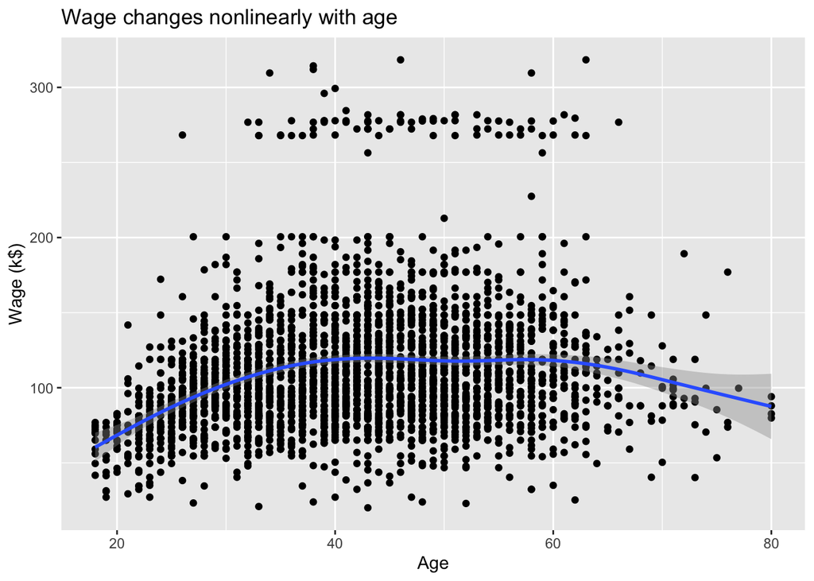

```r
# Plot wage ~ age, GAM fit is display when n >1000
Wage %>%
  ggplot(mapping = aes(x = age, y = wage)) +
  geom_point() +
  geom_smooth() +
  labs(title = "Wage changes nonlinearly with age",
       x = "Age",
       y = "Wage (k$)")
```

**Python**

```python
# Load the pandas library
import pandas as pd
# Load numpy for array manipulation
import numpy as np
# Load seaborn plotting library
import seaborn as sns
import matplotlib.pyplot as plt

# Set font size in plots
sns.set(font_scale = 1.2)
# Display all columns
pd.set_option('display.max_columns', None)

# Import Wage data
Wage = pd.read_csv("../data/Wage.csv")
Wage.info()
```

```
<class 'pandas.core.frame.DataFrame'>
RangeIndex: 3000 entries, 0 to 2999
Data columns (total 11 columns):
 #   Column      Non-Null Count  Dtype
---  ------      --------------  -----
 0   year        3000 non-null   int64
 1   age         3000 non-null   int64
 2   maritl      3000 non-null   object
 3   race        3000 non-null   object
 4   education   3000 non-null   object
 5   region      3000 non-null   object
 6   jobclass    3000 non-null   object
 7   health      3000 non-null   object
 8   health_ins  3000 non-null   object
 9   logwage     3000 non-null   float64
 10  wage        3000 non-null   float64
dtypes: float64(2), int64(2), object(7)
memory usage: 257.9+ KB
```

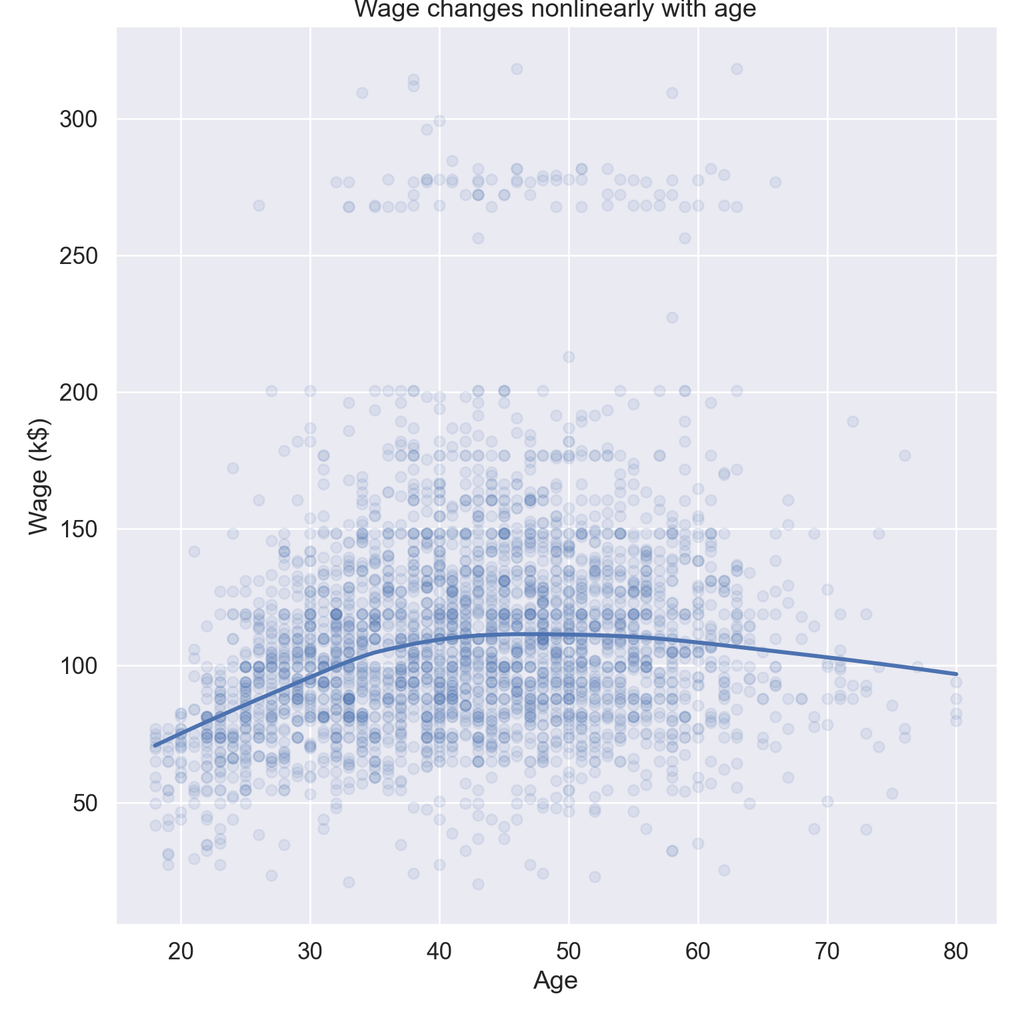

```python
# Visualize wage ~ age, display lowess curve
plt.figure()
sns.lmplot(
  data = Wage,
  x = "age",
  y = "wage",
  lowess = True,
  scatter_kws = {'alpha' : 0.1},
  height = 8
  ).set(
    title = "Wage changes nonlinearly with age",
    xlabel = 'Age',
    ylabel = 'Wage (k$)'
  );
plt.show()
```

## 2 Polynomial regression

In most of this lecture, consider $p=1$ in the following examples.
$$y_i = \beta_0 + \beta_1 x_i + \beta_2 x_i^2 + \cdots + \beta_d x_i^d + \epsilon_i.$$

**R**

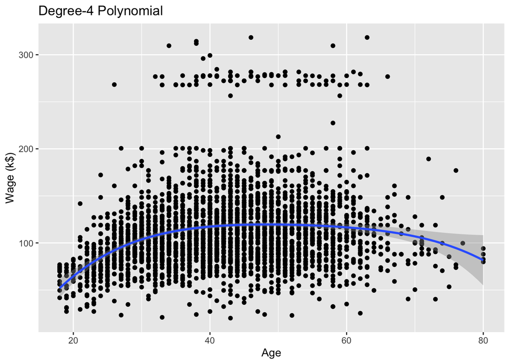

```r
# Plot wage ~ age, display order-4 polynomial fit
Wage %>%
  ggplot(mapping = aes(x = age, y = wage)) +
  geom_point() +
  geom_smooth(
    method = "lm",
    formula = y ~ poly(x, degree = 4)
    ) +
  labs(
    title = "Degree-4 Polynomial",
    x = "Age",
    y = "Wage (k$)"
    )
```

**Python**

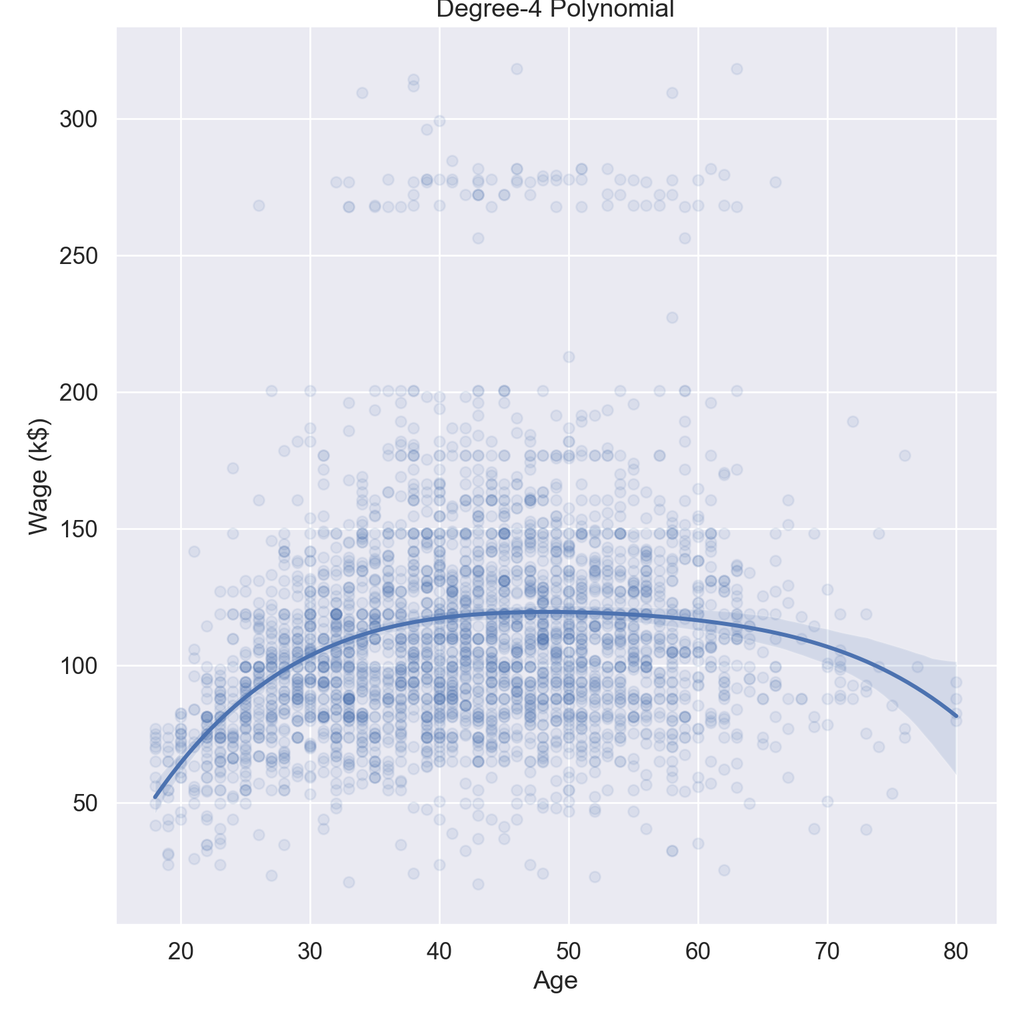

```python
# Visualize wage ~ age, display order-4 polynomial fit
plt.figure()
sns.lmplot(
  data = Wage,
  x = "age",
  y = "wage",
  # Order-4 polynomial regression
  order = 4,
  scatter_kws = {'alpha' : 0.1},
  height = 8
  ).set(
  xlabel = 'Age',
  ylabel = 'Wage (k$)',
  title = 'Degree-4 Polynomial'
  );
plt.show()
```

- Create new variables $X_1 = X$, $X_2 = X^2$, …, and then treat as multiple linear regression.
- Not really interested in the coefficients; more interested in the fitted function values at any value $x_0$:
  $$\hat f(x_0) = \hat{\beta}_0 + \hat{\beta}_1 x_0 + \hat{\beta}_2 x_0^2 + \hat{\beta}_3 x_0^3 + \hat{\beta}_4 x_0^4.$$

**R**

```r
# poly(age, 4) constructs orthogonal polynomial of degree 1 to degree, all orthogonal to the constant
lmod <- lm(wage ~ poly(age, degree = 4), data = Wage)
summary(lmod)
```

```
Call:
lm(formula = wage ~ poly(age, degree = 4), data = Wage)

Residuals:
    Min      1Q  Median      3Q     Max
-98.707 -24.626  -4.993  15.217 203.693

Coefficients:
                        Estimate Std. Error t value Pr(>|t|)
(Intercept)             111.7036     0.7287 153.283  < 2e-16 ***
poly(age, degree = 4)1  447.0679    39.9148  11.201  < 2e-16 ***
poly(age, degree = 4)2 -478.3158    39.9148 -11.983  < 2e-16 ***
poly(age, degree = 4)3  125.5217    39.9148   3.145  0.00168 **
poly(age, degree = 4)4  -77.9112    39.9148  -1.952  0.05104 .
---
Signif. codes:  0 '***' 0.001 '**' 0.01 '*' 0.05 '.' 0.1 ' ' 1

Residual standard error: 39.91 on 2995 degrees of freedom
Multiple R-squared:  0.08626,   Adjusted R-squared:  0.08504
F-statistic: 70.69 on 4 and 2995 DF,  p-value: < 2.2e-16
```

```r
# poly(age, 4, raw = TRUE) procudes raw othogonal polynomial, which match Python
lmod <- lm(wage ~ poly(age, degree = 4, raw = TRUE), data = Wage)
summary(lmod)
```

```
Call:
lm(formula = wage ~ poly(age, degree = 4, raw = TRUE), data = Wage)

Residuals:
    Min      1Q  Median      3Q     Max
-98.707 -24.626  -4.993  15.217 203.693

Coefficients:
                                     Estimate Std. Error t value Pr(>|t|)
(Intercept)                        -1.842e+02  6.004e+01  -3.067 0.002180 **
poly(age, degree = 4, raw = TRUE)1  2.125e+01  5.887e+00   3.609 0.000312 ***
poly(age, degree = 4, raw = TRUE)2 -5.639e-01  2.061e-01  -2.736 0.006261 **
poly(age, degree = 4, raw = TRUE)3  6.811e-03  3.066e-03   2.221 0.026398 *
poly(age, degree = 4, raw = TRUE)4 -3.204e-05  1.641e-05  -1.952 0.051039 .
---
Signif. codes:  0 '***' 0.001 '**' 0.01 '*' 0.05 '.' 0.1 ' ' 1

Residual standard error: 39.91 on 2995 degrees of freedom
Multiple R-squared:  0.08626,   Adjusted R-squared:  0.08504
F-statistic: 70.69 on 4 and 2995 DF,  p-value: < 2.2e-16
```

- Since $\hat f(x_0)$ is a linear function of the $\hat{\beta}_j$, we can get a simple expression for **pointwise-variances** $\operatorname{Var}[\hat f(x_0)]$ at any value $x_0$.
- We either fix the degree $d$ at some reasonably low value, or use cross-validation to choose $d$.
- Can do separately on several variables. Just stack the variables into one matrix, and separate out the pieces afterwards (see GAMs later).
- Polynomial modeling can be done for generalized linear models (logistic regression, Poisson regression, etc) as well.
- **Caveat**: polynomials have notorious tail behavior. Very bad for extrapolation.

**R**